# Linear Models with R

Clay Ford

3/25/2020

This file is available for download at https://uvastatlab.github.io/phdplus2020/ under the final session **Linear Modeling**.

## RStudio tips

- To submit a line of code, place your cursor in the line and hit
  - Ctrl + Enter (Win/Linux)
  - Cmd + Enter (Mac)
- To enter an assignment arrow (`<-`)
  - Alt + - (Win/Linux)
  - Option + - (Mac)

QUESTIONS? email `jcf2d@virginia.edu`

```r
# Load packages we'll use today
library(tidyverse)
library(ggeffects)
library(car)
library(splines)
library(stargazer)
```

## linear modeling with simulated data [Video, Part 1]

### Example 1: one numeric predictor

Let’s begin by simulating some fake data

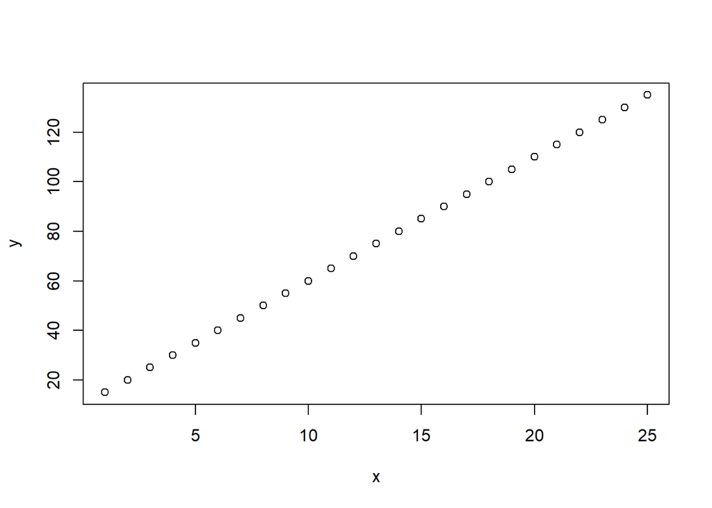

```r
x <- 1:25
y <- 10 + 5*x
plot(x, y)
```

10 is the intercept, 5 is the slope. y is completely determined by x

Let’s add some “noise” to our data by adding random draws from a Normal distribution with mean = 0 and a standard deviation = 10.

`set.seed(1)` ensures we all get the same “random” data

```r
set.seed(1)
noise <- rnorm(n = 25, mean = 0, sd = 10)
```

Add the noise to 10 + 5*x and re-draw plot

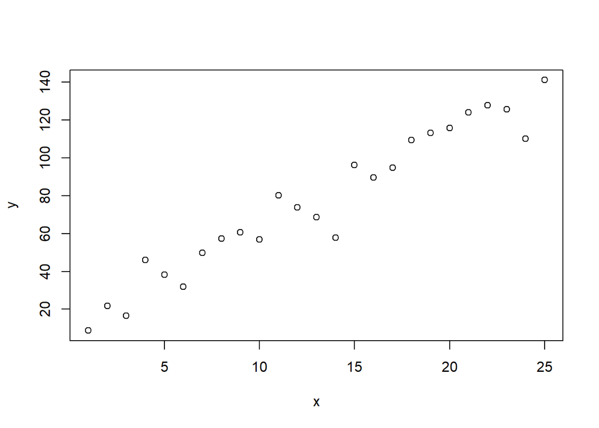

```r
y <- 10 + 5*x + noise
plot(x, y)
```

This data is the combination of two parts:

1. 10 + 5*x
2. rnorm(n = 25, mean = 0, sd = 10)

What if we were given this data and told to determine the process that generated it? In other words, fill in the blanks:

1. __ + __*x
2. rnorm(n = 25, mean = 0, sd = ____)

That’s basically what linear modeling is.

Traditional linear modeling assumes the following (among others):

1. the formula is a weighted sum of predictors (eg, 10 + 5*x)
2. the noise is a random draw from a Normal distribution with mean = 0
3. the standard deviation of the Normal distribution is constant

Linear modeling tries to recover the weights in the first assumption (10 and 5) and the standard deviation in the 3rd assumption (10).

Let’s attempt to recover the data generating process. For this we use the `lm()` function. We have to specify the formula for the first assumption. The 2nd and 3rd assumptions are built into `lm()`.

“y ~ x” means we think Part 1 of the model is "y = intercept + slope*x". This tells `lm()` to take our data and find the best intercept and slope. Notice this is the correct model!

```r
mod <- lm(y ~ x)
summary(mod)
```

```
##
## Call:
## lm(formula = y ~ x)
##
## Residuals:
##     Min      1Q  Median      3Q     Max
## -23.876  -4.613   2.254   5.909  14.648
##
## Coefficients:
##             Estimate Std. Error t value Pr(>|t|)
## (Intercept)   11.135      3.999   2.784   0.0105 *
## x              5.042      0.269  18.743 1.98e-15 ***
## ---
## Signif. codes:  0 '***' 0.001 '**' 0.01 '*' 0.05 '.' 0.1 ' ' 1
##
## Residual standard error: 9.7 on 23 degrees of freedom
## Multiple R-squared:  0.9386, Adjusted R-squared:  0.9359
## F-statistic: 351.3 on 1 and 23 DF,  p-value: 1.981e-15
```

The model returns the following estimates:

intercept = 11.135 slope = 5.042 sd = 9.7 (Residual standard error)

Recall the “true” values:

intercept = 10 slope = 5 sd = 10

We could use those estimates to generate data and see if they look similar to our original data.

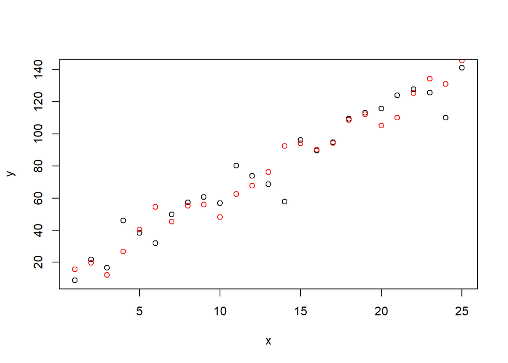

```r
y2 <- 11.135 + 5.042*x + rnorm(25, 0, 9.7)
# plot original data
plot(x, y)
# plot simulated data using estimates
points(x, y2, col = "red")
```

Looks similar.

We could also add the original and fitted lines

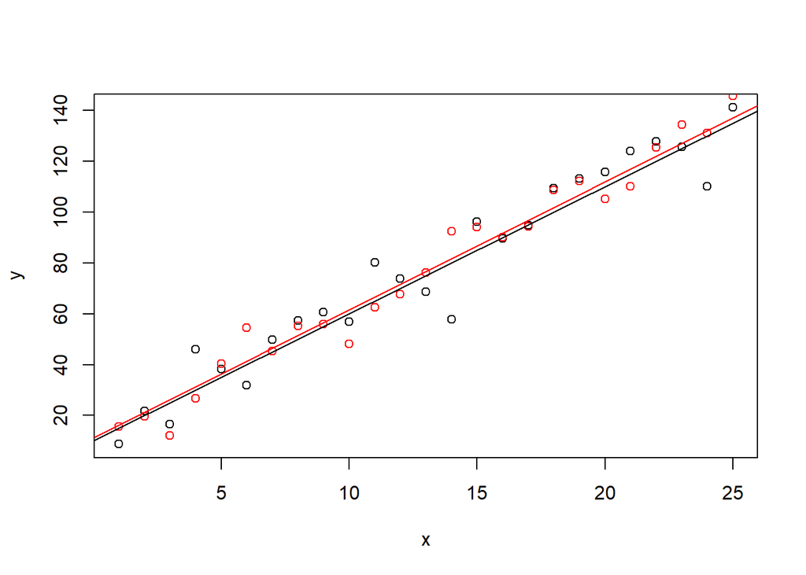

```r
plot(x, y)
points(x, y2, col = "red")
# a = intercept, b = slope
abline(a = 10, b = 5)
abline(mod, col = "red")
```

We could also compare distributions using histograms

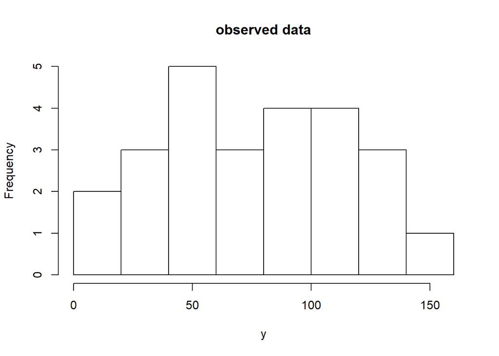

```r
hist(y, main = "observed data")
```

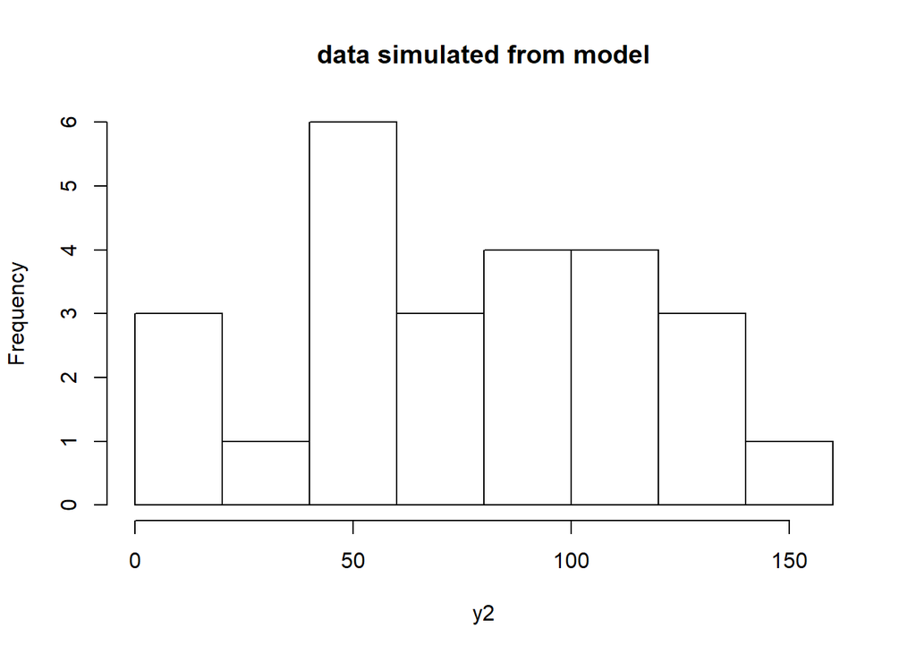

```r
hist(y2, main = "data simulated from model")
```

Or we could compare using density curves (smooth version of histograms)

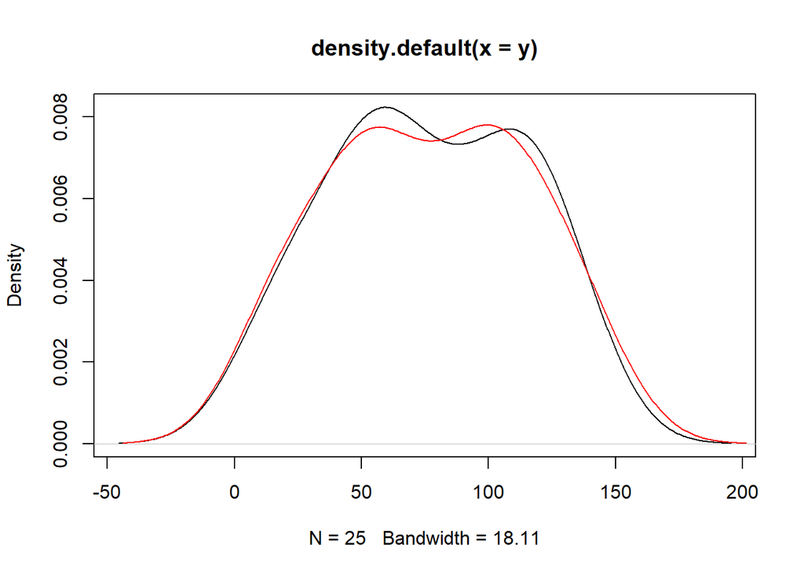

```r
plot(density(y))
lines(density(y2), col = "red")
```

In real life, we DO NOT KNOW the formula of weighted sums, or even if a formula of weighted sums is appropriate. We also don’t know if the Normality assumption or constant variance assumption of the noise is plausible.

## linear modeling with simulated data [Video, Part 2]

### Example 2: one categorical and one numeric predictor

Again, let’s simulate some data. The function `set.seed(15)` ensures we all generate the same data.

```r
set.seed(15)

# random sample of "m" and "f"
gender <- sample(c("m", "f"), size = 200, replace = TRUE)

# random numbers from the range of 1 - 20
score <- runif(n = 200, min = 1, max = 20)

# the noise: random draws from a N(0,5) distribution
noise <- rnorm(n = 200, mean = 0, sd = 5)
```

Now we simulate y. The third predictor is an “interaction”. That is, the “effect” of score depends on gender.

```r
y <- -1 + -3*(gender=="m") + 2*score + 3*(gender=="m")*score + noise
dat <- data.frame(y, gender, score)
```

Scatter plot of y versus x, colored by gender. Now ggplot2 comes in handy.

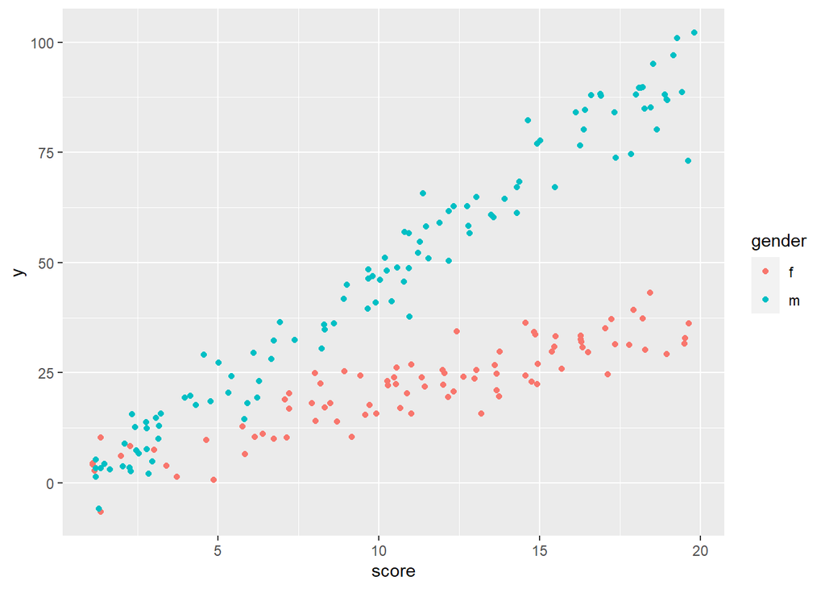

```r
ggplot(dat, aes(x = score, y = y, color = gender)) +
  geom_point()
```

Notice the distribution of y is not Normal. That’s OK. The normality assumption is for the noise/error.

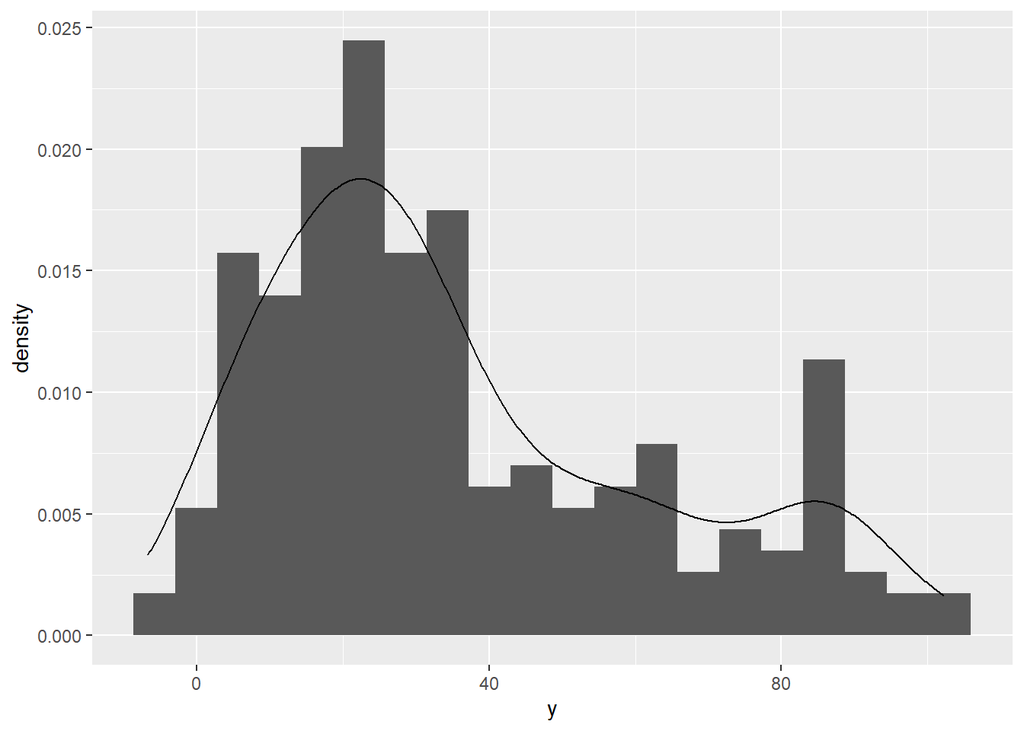

```r
ggplot(dat, aes(x = y, y = stat(density))) +
  geom_histogram(bins = 20) +
  geom_density()
```

Let’s try to recover the “true” values in the formula and the SD of the noise.

To fit an interaction, use a colon.

```r
mod2 <- lm(y ~ gender + score + gender:score, data = dat)
# or more concisely
mod2 <- lm(y ~ gender * score, data = dat)
```

We come pretty close to recovering the true values…

```r
# y <- -1 + -3*(gender=="m") + 2*score + 3*(gender=="m")*score + noise
summary(mod2)
```

```
##
## Call:
## lm(formula = y ~ gender * score, data = dat)
##
## Residuals:
##      Min       1Q   Median       3Q      Max
## -21.4835  -3.4282   0.1576   3.4301  12.7603
##
## Coefficients:
##               Estimate Std. Error t value Pr(>|t|)
## (Intercept)     1.1841     1.3389   0.884  0.37758
## genderm        -5.3155     1.6563  -3.209  0.00156 **
## score           1.8227     0.1090  16.726  < 2e-16 ***
## genderm:score   3.2059     0.1372  23.363  < 2e-16 ***
## ---
## Signif. codes:  0 '***' 0.001 '**' 0.01 '*' 0.05 '.' 0.1 ' ' 1
##
## Residual standard error: 5.12 on 196 degrees of freedom
## Multiple R-squared:  0.9631, Adjusted R-squared:  0.9625
## F-statistic:  1704 on 3 and 196 DF,  p-value: < 2.2e-16
```

Let’s simulate data from our model and see how it compares to the original data. For this we can use the `simulate()` function

```r
sim_y <- simulate(mod2)
head(sim_y)
```

```
##      sim_1
## 1 42.19224
## 2 67.73883
## 3 10.33191
## 4 31.29291
## 5 22.11217
## 6 24.98789
```

plot both `y` and `sim.y` and compare. This time we use ggplot2.

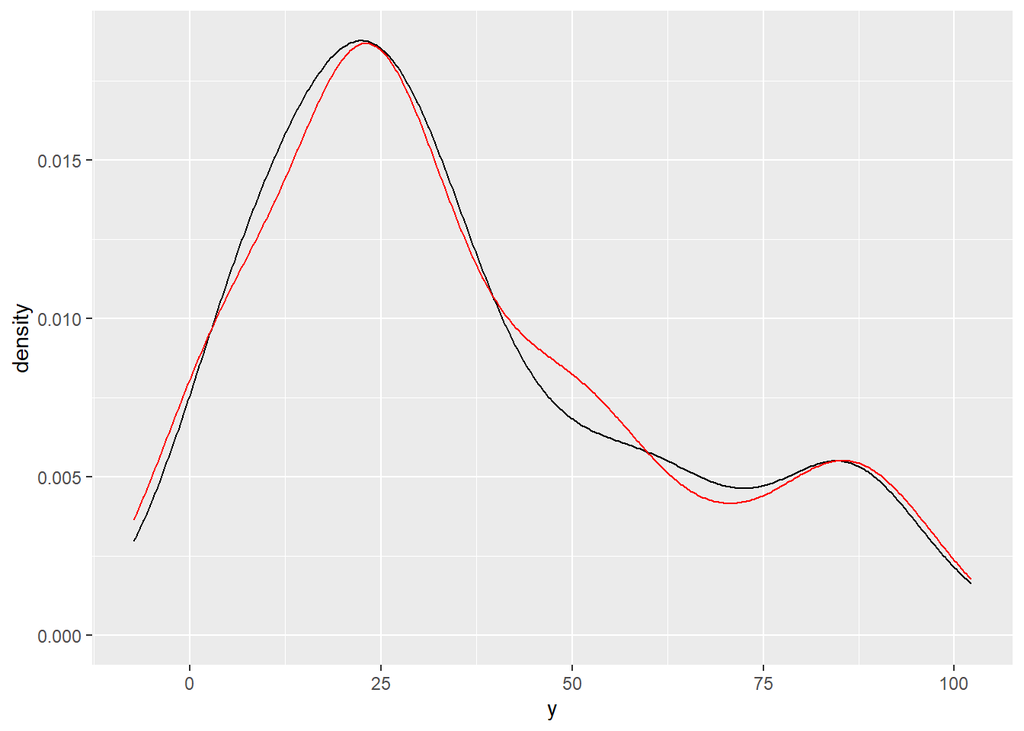

```r
ggplot(dat, aes(x = y)) +
  geom_density() +
  geom_density(aes(sim_1), sim_y, color = "red")
```

Or the base R way

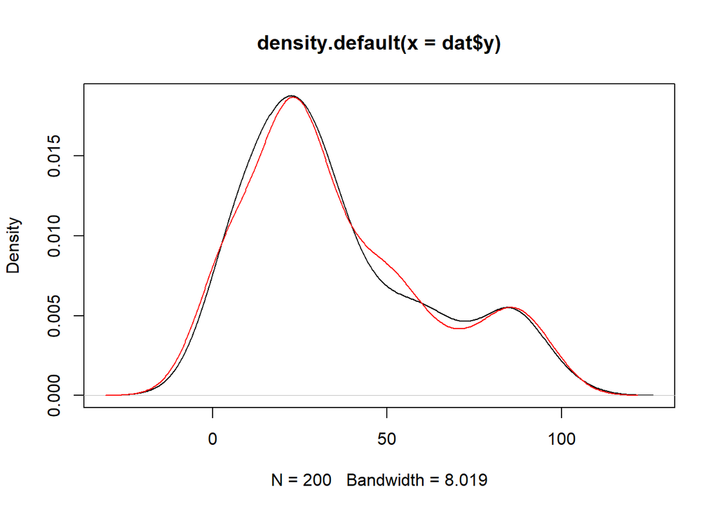

```r
plot(density(dat$y))
lines(density(sim_y$sim_1), col = "red")
```

By specifying geom_smooth(method = “lm”) in the ggplot2 call we can add the fitted lines.

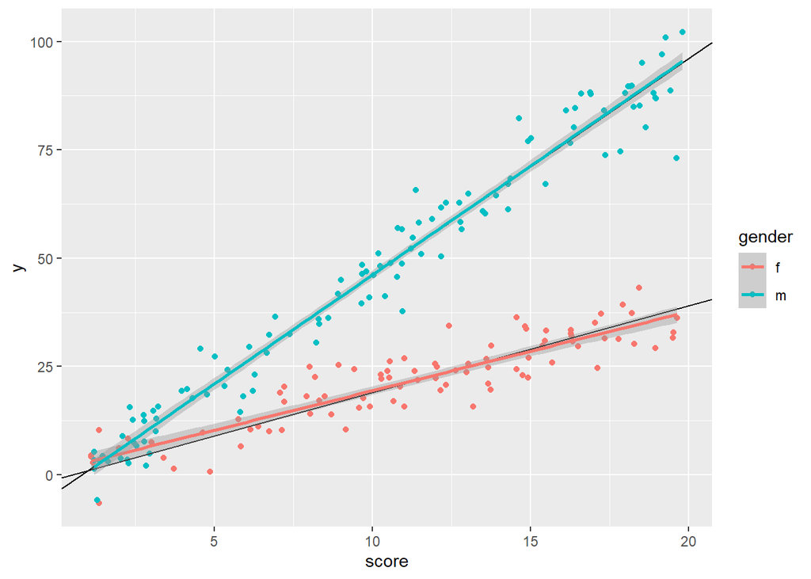

```r
ggplot(dat, aes(x = score, y = y, color = gender)) +
  geom_point() +
  geom_abline(intercept = -1, slope = 2) +  # true line for "f"
  geom_abline(intercept = -4, slope = 5) +  # true line for "m"
  geom_smooth(method = "lm")                # model predicted lines
```

Probably better to use the model to create the plot. These are usually referred to as “effect plots”. Here we use the `ggpredict()` function from the ggeffects package.

```r
eff <- ggpredict(mod2, terms = c("score", "gender"))
eff
```

```
##
## # Predicted values of y
## # x = score
##
## # gender = f
##
##  x | Predicted |   SE |         95% CI
## --------------------------------------
##  0 |      1.18 | 1.34 | [-1.44,  3.81]
##  5 |     10.30 | 0.87 | [ 8.59, 12.00]
## 10 |     19.41 | 0.56 | [18.32, 20.51]
## 15 |     28.52 | 0.68 | [27.19, 29.86]
## 20 |     37.64 | 1.10 | [35.48, 39.79]
##
## # gender = m
##
##  x | Predicted |   SE |         95% CI
## --------------------------------------
##  0 |     -4.13 | 0.98 | [-6.04, -2.22]
##  5 |     21.01 | 0.65 | [19.74, 22.28]
## 10 |     46.15 | 0.49 | [45.20, 47.11]
## 15 |     71.30 | 0.63 | [70.06, 72.54]
## 20 |     96.44 | 0.96 | [94.57, 98.31]
```

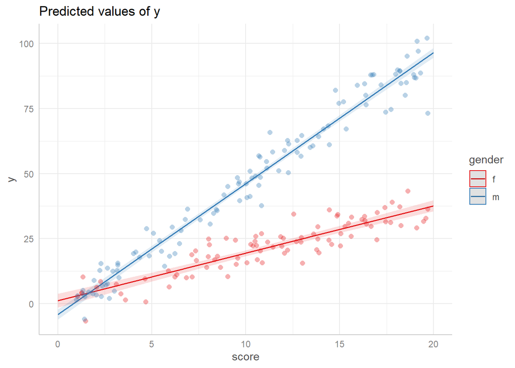

```r
plot(eff, add.data = TRUE)
```

Let’s fit a “wrong” model with no interaction.

“y ~ gender + score” means “y = intercept + b1 * gender + b2 * score”

The effect of score is the same for both males and female

```r
mod3 <- lm(y ~ gender + score, data = dat)
summary(mod3)
```

```
##
## Call:
## lm(formula = y ~ gender + score, data = dat)
##
## Residuals:
##     Min      1Q  Median      3Q     Max
## -22.137  -7.288  -0.479   6.739  26.620
##
## Coefficients:
##             Estimate Std. Error t value Pr(>|t|)
## (Intercept) -21.5267     1.7868  -12.05   <2e-16 ***
## genderm      29.3970     1.4206   20.69   <2e-16 ***
## score         3.8447     0.1285   29.92   <2e-16 ***
## ---
## Signif. codes:  0 '***' 0.001 '**' 0.01 '*' 0.05 '.' 0.1 ' ' 1
##
## Residual standard error: 9.935 on 197 degrees of freedom
## Multiple R-squared:  0.8602, Adjusted R-squared:  0.8588
## F-statistic: 606.3 on 2 and 197 DF,  p-value: < 2.2e-16
```

Compare simulated data to oberserved data; not good!

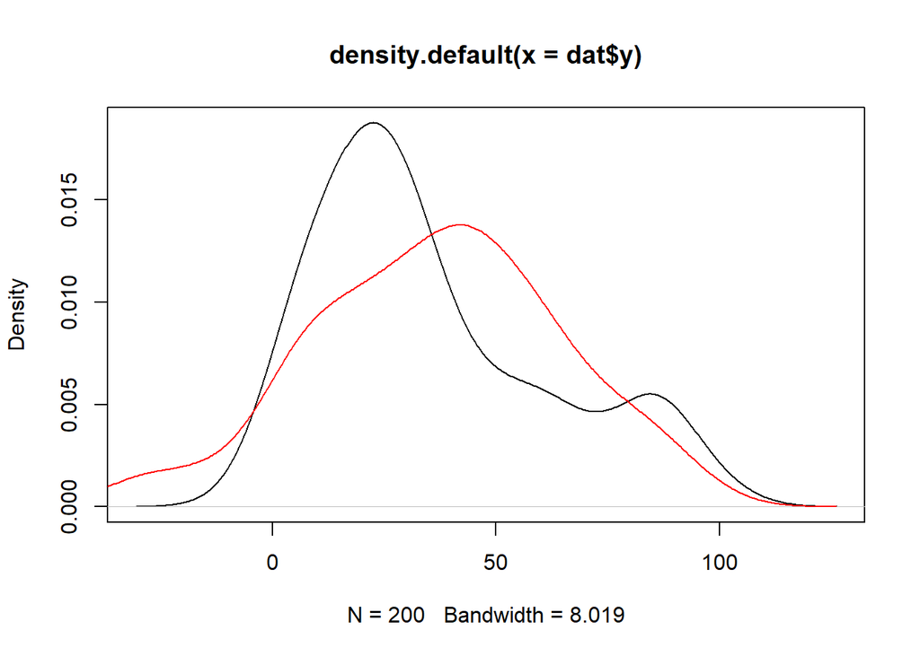

```r
sim_y <- simulate(mod3)
plot(density(dat$y))
lines(density(sim_y$sim_1), col = "red")
```

Plot the fitted model using `ggpredict`

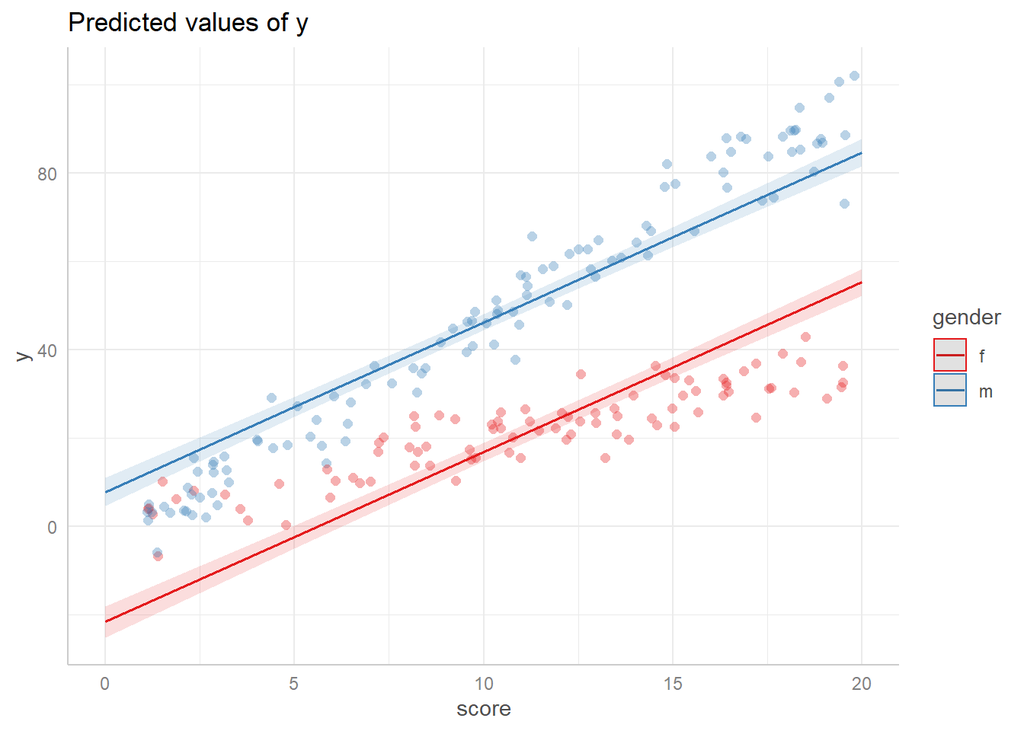

```r
eff <- ggpredict(mod3, terms = c("score", "gender"))
plot(eff, add.data = TRUE)
```

Hence this is linear modeling:

1. propose and fit model(s)
2. determine if the model is good
3. use the model to explain relationships or make predictions

## YOUR TURN #1

```r
# submit the following code to simulate some data
set.seed(2)
x1 <- sample(1:5, size = 1000, replace = TRUE,
             prob = c(0.1,0.2,0.3,0.3,0.1))
x2 <- rnorm(n = 1000, mean = 12, sd = 2)
noise <- rnorm(n = 1000, mean = 0, sd = 4)
y <- 5 + 10*x1 + -4*x2 + noise
df <- data.frame(y, x1, x2)
head(df)

# Use lm() as we did above to attempt to recover the "true" values that were
# used to generate y.
```

## linear modeling with Albemarle County Real Estate data [Video, Part 3]

Recall we (David Martin) downloaded and cleaned over 30,000 records from Albemarle County’s office of Geographic Data Services. The final clean version is available as an RDS file on GitHub. The following code will download the file and read into R. Notice we have to assign the result of `readRDS` to a name. This creates an object in our workspace called “homes”.

```r
URL <- "https://github.com/uvastatlab/phdplus2020/raw/master/data/homes_final.rds"
homes <- readRDS(file = url(URL))
glimpse(homes)
```

```
## Observations: 30,258
## Variables: 23
## $ yearbuilt         <dbl> 1939, 1981, 1999, 1754, 1880, 1769, 1818, 1935, 1...
## $ yearremodeled     <dbl> NA, NA, NA, NA, NA, 1988, 1991, 1994, 1978, NA, N...
## $ usecode           <chr> "Single Family", "Single Family", "Single Family"...
## $ finsqft           <dbl> 1596, 1616, 480, 828, 1224, 4875, 5573, 1120, 145...
## $ cooling           <fct> No Central Air, No Central Air, No Central Air, N...
## $ bedroom           <dbl> 3, 6, 0, 1, 2, 4, 6, 3, 3, 3, 3, 3, 3, 3, 3, 4, 2...
## $ fullbath          <dbl> 1, 4, 0, 0, 1, 3, 4, 1, 1, 3, 2, 2, 3, 3, 2, 1, 1...
## $ halfbath          <dbl> 0, 0, 0, 0, 0, 0, 1, 0, 0, 0, 1, 0, 0, 0, 1, 0, 0...
## $ totalrooms        <dbl> 5, 9, 1, 3, 4, 8, 11, 5, 6, 6, 9, 0, 10, 8, 8, 6,...
## $ lotsize           <dbl> 55.955, 5.167, 80.750, 80.718, 65.000, 5.102, 453...
## $ landvalue         <dbl> 347900, 140300, 312500, 327100, 497000, 106400, 1...
## $ improvementsvalue <dbl> 80700, 212300, 21600, 13500, 113100, 827000, 8022...
## $ totalvalue        <dbl> 428600, 352600, 334100, 340600, 610100, 933400, 2...
## $ lastsaleprice     <dbl> 424000, 300000, 0, 0, 0, 0, 0, 2820000, 0, 0, 520...
## $ esdistrict        <fct> Broadus Wood, Broadus Wood, Broadus Wood, Broadus...
## $ msdistrict        <fct> Jouett, Jouett, Jouett, Jouett, Jouett, Henley, H...
## $ hsdistrict        <fct> Albemarle, Albemarle, Albemarle, Albemarle, Albem...
## $ censustract       <fct> 101, 101, 101, 101, 101, 101, 101, 101, 101, 101,...
## $ lastsaledate      <date> 2003-11-18, 2012-03-23, 1994-06-30, 1994-08-09, ...
## $ age               <dbl> 80, 38, 20, 265, 139, 250, 201, 84, 139, 14, 15, ...
## $ condition         <fct> Fair, Average, Average, Substandard, Fair, Averag...
## $ remodel           <dbl> 0, 0, 0, 0, 0, 1, 1, 1, 1, 0, 0, 0, 0, 0, 0, 0, 0...
## $ fp                <dbl> 0, 1, 0, 0, 1, 1, 1, 0, 1, 1, 1, 1, 1, 1, 1, 0, 0...
```

Notice we have a lot of variability in totalvalue of the home.

```r
summary(homes$totalvalue)
```

```
##    Min. 1st Qu.  Median    Mean 3rd Qu.    Max.
##    4300  243500  340500  424524  491300 7859000
```

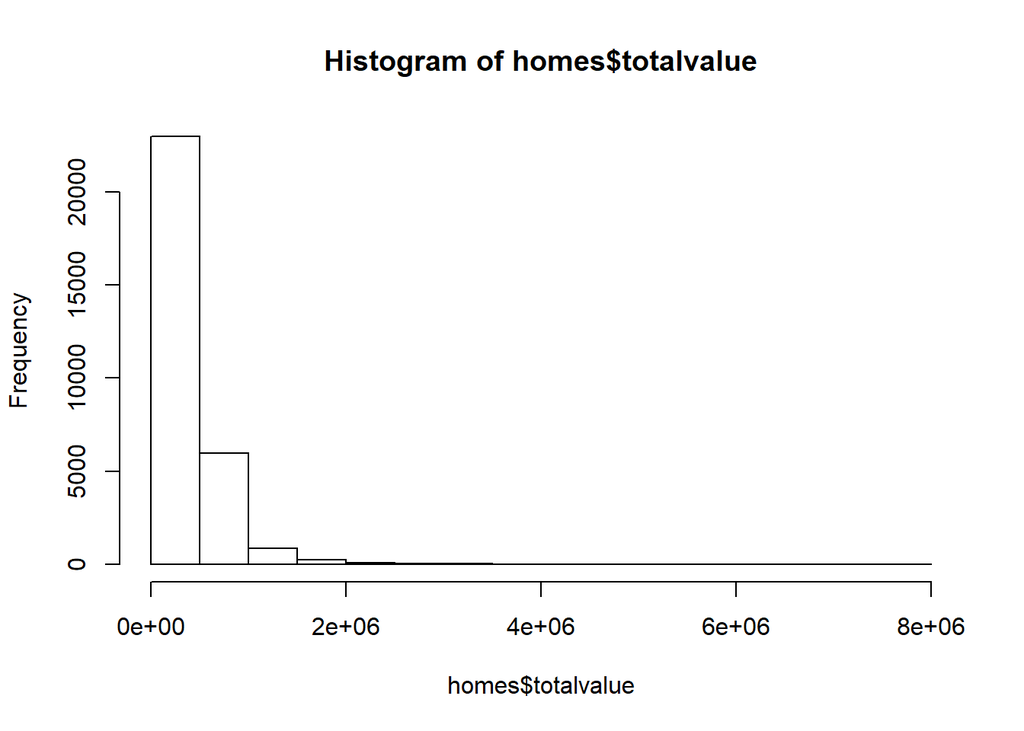

```r
hist(homes$totalvalue)
```

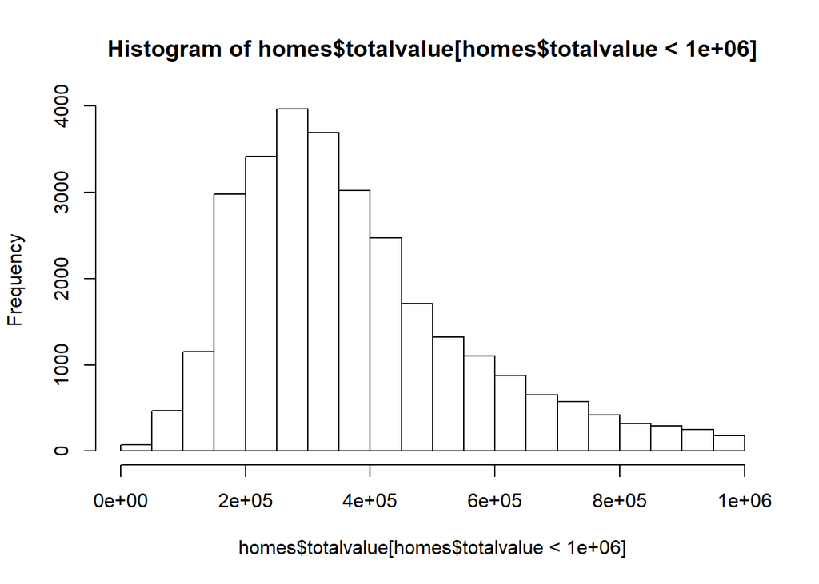

```r
# homes less than $1,000,000
hist(homes$totalvalue[homes$totalvalue < 1e6])
```

Perhaps we could build a linear model to help us understand that variability and estimate the expected totalvalue of a home given various predictors such as finsqft, censustract, bedrooms, lotsize, cooling, etc. Let’s try that with finsqft.

Below we propose that totalvalue = Intercept + slope * finsqft + noise, where noise is assumed to be drawn from a Normal distribution with mean 0 and some unknown standard deviation. Therefore we are estimating three quantities:

1. Intercept
2. slope coefficient for finsqft
3. standard deviation of the Normal distribution with mean = 0

```r
plot(totalvalue ~ finsqft, data = homes)
m1 <- lm(totalvalue ~ finsqft, data = homes)
summary(m1)
```

```
##
## Call:
## lm(formula = totalvalue ~ finsqft, data = homes)
##
## Residuals:
##      Min       1Q   Median       3Q      Max
## -1192704   -85548   -14220    50496  6376635
##
## Coefficients:
##               Estimate Std. Error t value Pr(>|t|)
## (Intercept) -1.472e+05  3.082e+03  -47.76   <2e-16 ***
## finsqft      2.761e+02  1.351e+00  204.28   <2e-16 ***
## ---
## Signif. codes:  0 '***' 0.001 '**' 0.01 '*' 0.05 '.' 0.1 ' ' 1
##
## Residual standard error: 224600 on 30256 degrees of freedom
## Multiple R-squared:  0.5797, Adjusted R-squared:  0.5797
## F-statistic: 4.173e+04 on 1 and 30256 DF,  p-value: < 2.2e-16
```

```r
coef(m1)
```

```
##  (Intercept)      finsqft
## -147204.5943     276.0597
```

```r
sigma(m1)
```

```
## [1] 224574.9
```

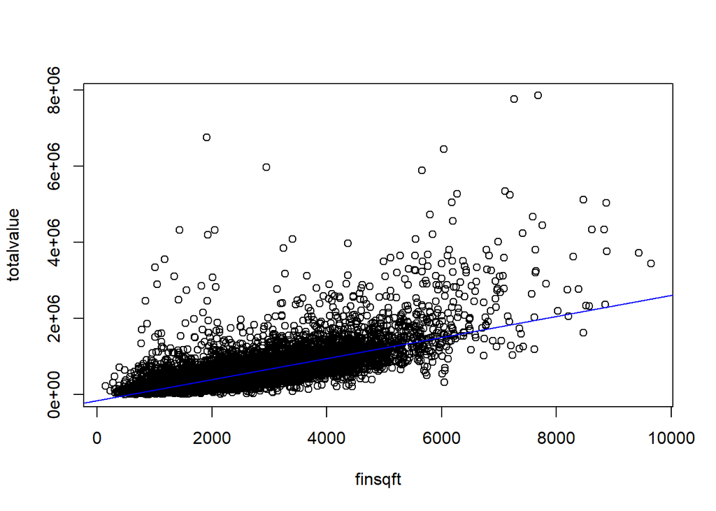

```r
# can add the fitted line to our plot
abline(m1, col = "blue")
```

A naive interpretation: - Every additional square foot adds about $276 to the total value of a home.

An informal check of the “goodness” of this model is to use it to generate data and then compare that data to the original data. Below we use `simulate` to generate 50 sets of totalvalues from our model. Then we plot the density of the observed totalvalue and overlay it with the densities of the simulations.

The syntax `sim1[[i]]` extracts the ith column of the sim1 data frame.

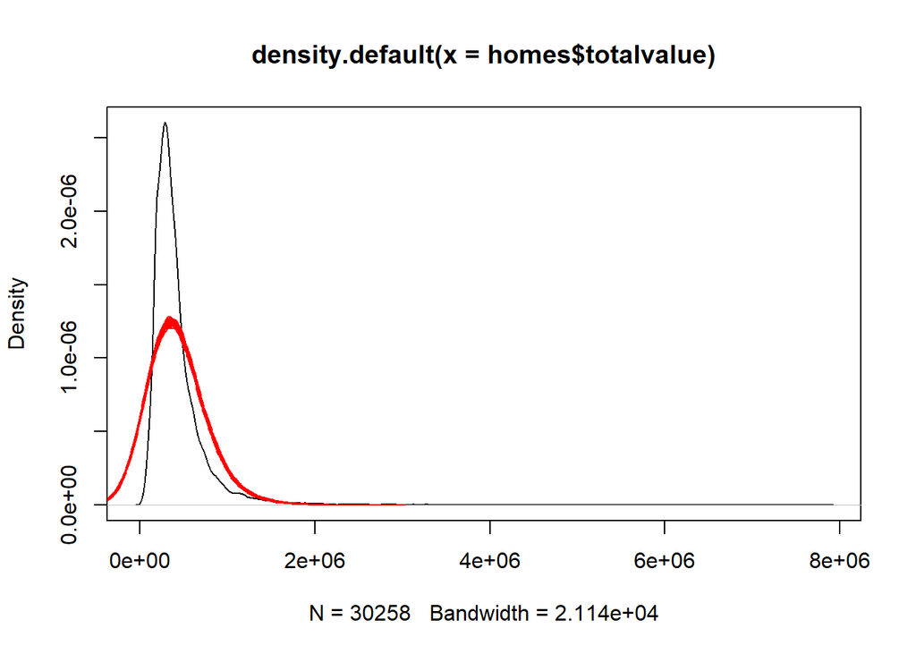

```r
sim1 <- simulate(m1, nsim = 50)
plot(density(homes$totalvalue))
for(i in 1:50)lines(density(sim1[[i]]), col = "red")
```

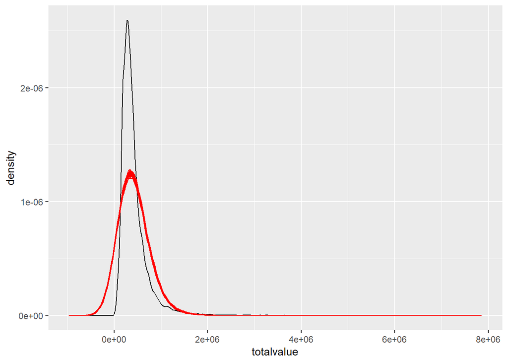

```r
# tidyverse method - slower, more complicated
ggplot(homes, aes(x = totalvalue)) +
  geom_line(stat = "density") +
  geom_line(aes(x = totalvalue, group = sim),
               pivot_longer(sim1, everything(),
                            names_to = "sim",
                            values_to = "totalvalue"),
            stat = "density",
            color = "red")
```

This doesn’t look good.

Recall our assumptions:

1. the formula is a weighted sum of predictors (eg, 10 + 5*x)
2. the noise is a random draw from a Normal distribution with mean = 0
3. the standard deviation of the Normal distribution is constant

Calling `plot` on our model object produces a series of plots to assess those last two assumptions.

Let’s see what these plots look like when the model assumptions are satisfied. We simulated the data for `mod2` using these assumptions and then fit the correct model.

```r
summary(mod2)
```

```
##
## Call:
## lm(formula = y ~ gender * score, data = dat)
##
## Residuals:
##      Min       1Q   Median       3Q      Max
## -21.4835  -3.4282   0.1576   3.4301  12.7603
##
## Coefficients:
##               Estimate Std. Error t value Pr(>|t|)
## (Intercept)     1.1841     1.3389   0.884  0.37758
## genderm        -5.3155     1.6563  -3.209  0.00156 **
## score           1.8227     0.1090  16.726  < 2e-16 ***
## genderm:score   3.2059     0.1372  23.363  < 2e-16 ***
## ---
## Signif. codes:  0 '***' 0.001 '**' 0.01 '*' 0.05 '.' 0.1 ' ' 1
##
## Residual standard error: 5.12 on 196 degrees of freedom
## Multiple R-squared:  0.9631, Adjusted R-squared:  0.9625
## F-statistic:  1704 on 3 and 196 DF,  p-value: < 2.2e-16
```

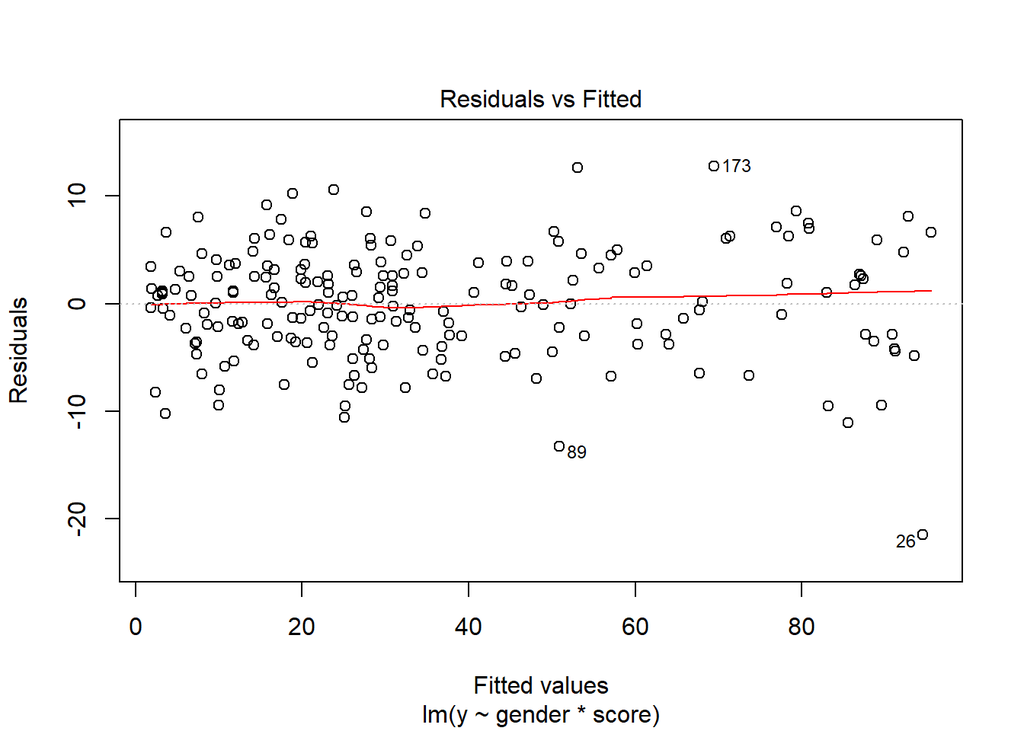

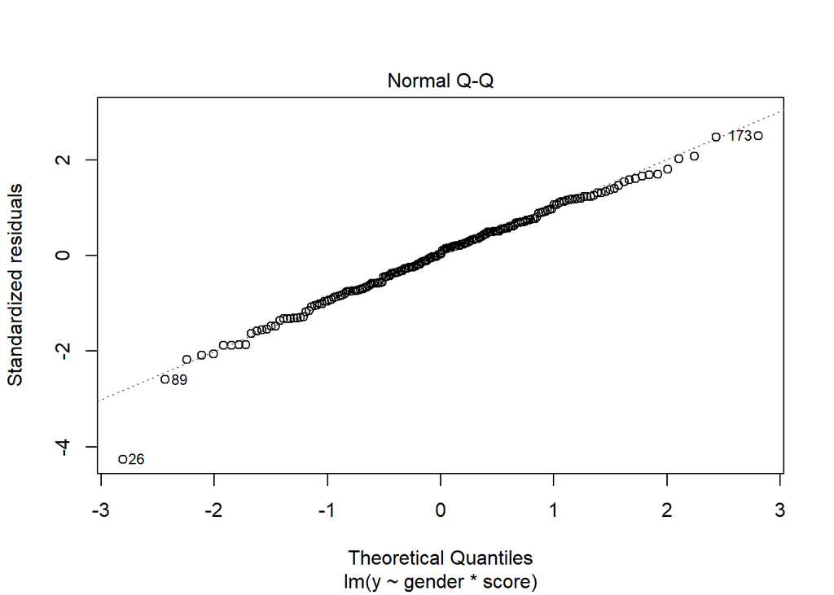

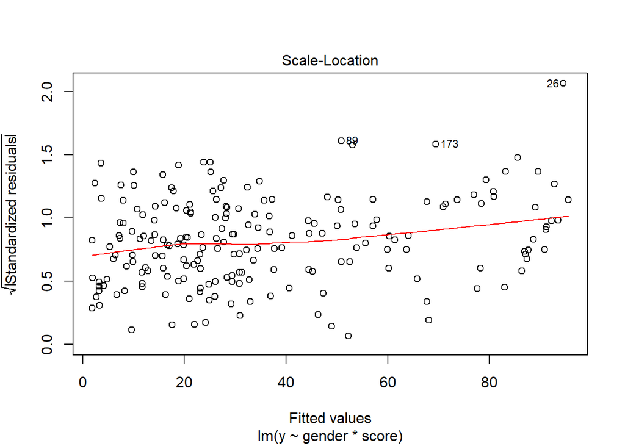

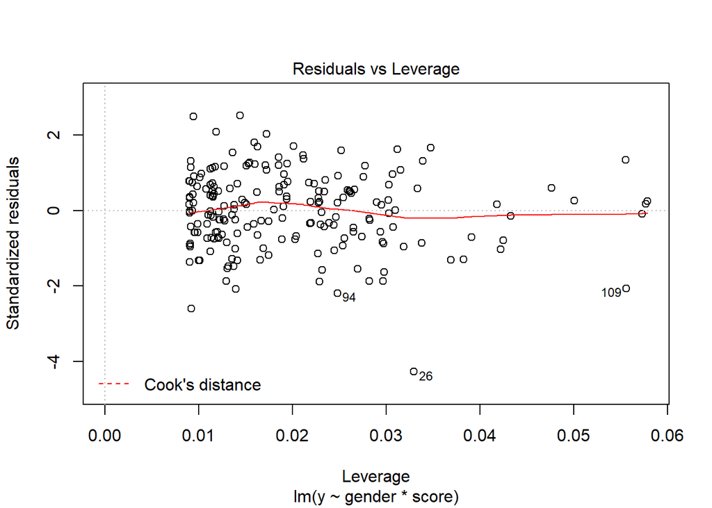

```r
plot(mod2)
```

*How to interpret plots*

1. Residuals vs Fitted: should have a horizontal line with uniform and symmertic scatter of points; if not, evidence that SD is not constant
2. Normal Q-Q: points should lie close to diagonal line; if not, evidence that noise is not drawn from N(0, SD)
3. Scale-Location: should have a horizontal line with uniform scatter of point; (similar to #1 but easier to detect trend in dispersion)
4. Residuals vs Leverage: points outside the contour lines are influential observations

Let’s look at the diagnostic plots for our homes model.

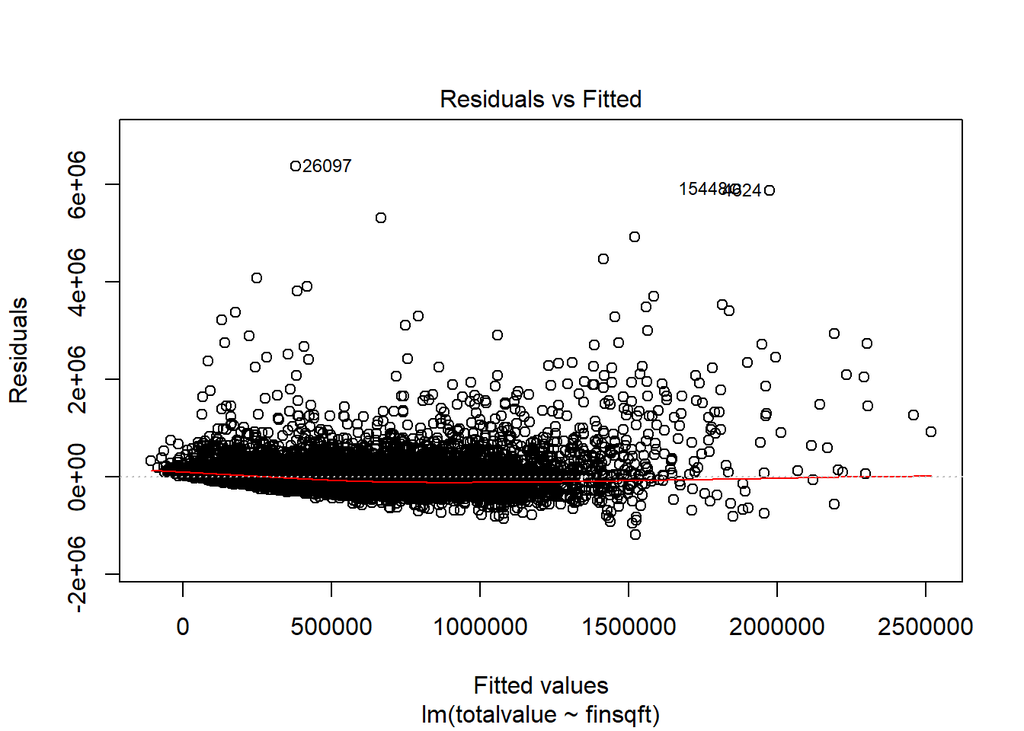

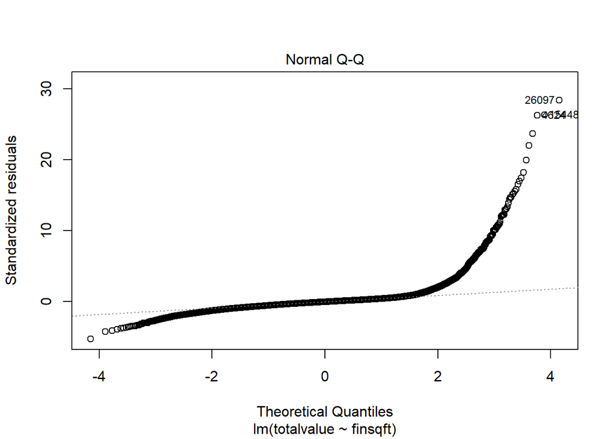

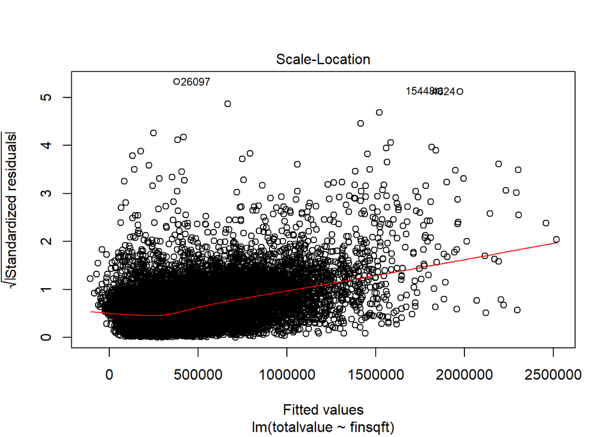

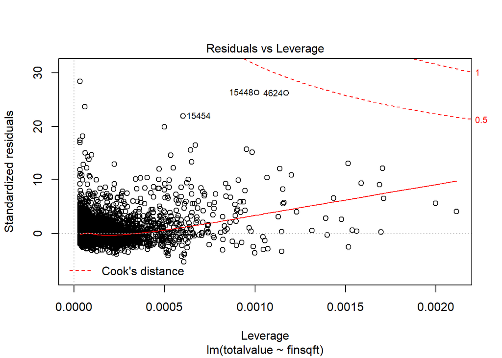

```r
plot(m1)
```

Plots 1, 2, and 3 are very concerning

How to address concerns?